# Visualização de Features e Detecção de Conceitos

## O que o atlas revela

Olhando o atlas filtrado pela classe “tubarão-branco”, os autores acharam um detector que também dispara na costura vermelha de bolas de beisebol. Então colaram uma bola numa foto de baleia:

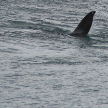

**baleia-cinzenta** 91,0%

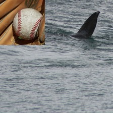

**tubarão-branco** 66,7%

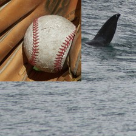

**bola de beisebol** 100,0%

**Features de uso múltiplo**

Detectores que respondem a coisas diferentes, mas parecidas: a locomotiva a vapor ajuda a achar os cilindros de mergulho de “mergulhador”; macarrão separa “wok” de “frigideira”.

**Ataques feitos por humanos**

Patches escolhidos olhando o atlas trocam a classe em cerca de 2 de cada 5 imagens da classe (1.000 imagens de treino por classe).

**Limites**

Só mostra ativações que ocorrem na amostra; não mostra como elas se combinam; e depende dos hiperparâmetros da redução de dimensionalidade e da grade.

[Carter et al. (2019)](https://distill.pub/2019/activation-atlas/), *Focusing on a Single Classification*, *Testing dozens of patches* e *Technical Notes and Limitations*: imagens do ImageNet e probabilidades do InceptionV1 publicadas no artigo, CC BY 4.0.

# Network Dissection

## Uma unidade, um conceito?

As visualizações sugerem conceitos (“focinho”, “céu”), mas não provam nada, nem dizem quão bem uma unidade detecta um conceito. Por trás da pergunta há uma hipótese: as unidades aprendem conceitos **desemaranhados** (*disentangled*).

**Se fosse assim**

Cada canal detectaria um conceito do mundo: o 394, arranha-céus; o 121, focinhos de cachorro. Daria para seguir a decisão: a unidade “husky” depende das unidades “focinho”, “pelo” e “neve”? Então um husky na neve pode virar lobo. E daria para achar vieses: há uma unidade “pele branca” ajudando a prever salário?

**O oposto**

Numa rede totalmente emaranhada, nenhuma unidade isolada corresponde a focinhos: todas contribuem um pouco. Spoiler: as CNNs não são perfeitamente desemaranhadas.

Network Dissection troca o “parece” por um número: quanto as ativações mais fortes de uma unidade coincidem, pixel a pixel, com um conceito rotulado por humanos.

[Molnar (2025), *Network Dissection*](https://christophm.github.io/interpretable-ml-book/cnn-features.html#network-dissection), *The Question of Disentangled Features*; [Bau, Zhou, Khosla, Oliva e Torralba (2017)](https://arxiv.org/abs/1704.05796), §1.

## Conceitos rotulados pixel a pixel

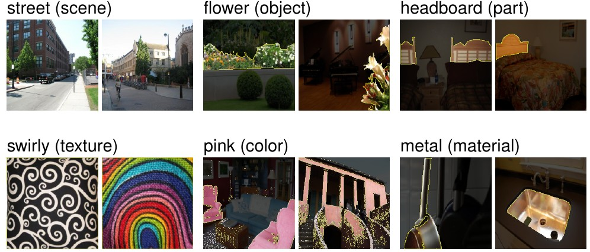

| categoria | conceitos | fonte |
| --- | --- | --- |
| cena | 468 | ADE |
| objeto | 584 | ADE, Pascal-Context |
| parte | 234 | ADE, Pascal-Part |
| material | 32 | OpenSurfaces |
| textura | 47 | DTD |
| cor | 11 | gerada |

O **Broden** (*Broadly and Densely Labeled Dataset*) junta cinco bases rotuladas pixel a pixel; cenas e texturas são rótulos da imagem inteira. Na reprodução, um “Broden” do MNIST, com máscaras calculadas por regras:

[figure not shown]

[Bau et al. (2017)](https://arxiv.org/abs/1704.05796), §2.1, tab. 1 e fig. 2. Mini-Broden: tinta (≈ cor), bordas do traço (≈ textura), orientação pelo tensor de estrutura, buraco, pontas e junções do esqueleto do traço ([Zhang e Suen, 1984](https://doi.org/10.1145/357994.358023)) e a classe do dígito como rótulo da imagem (≈ cena): 23 conceitos.

## O algoritmo

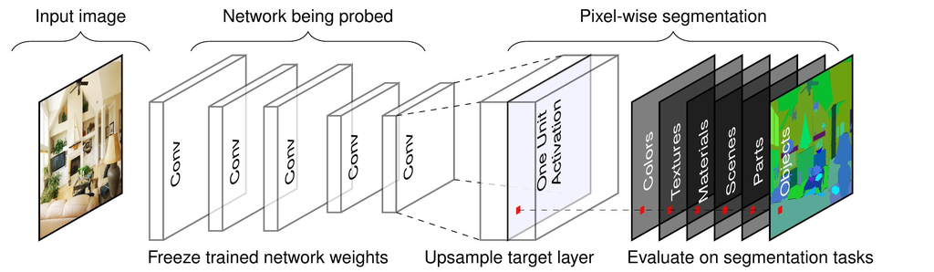

$$P\big(a_k>T_k\big)=0{,}005,\qquad M_k(\mathbf x)=S_k(\mathbf x)\ge T_k,\qquad
\mathrm{IoU}_{k,c}=\frac{\sum_{\mathbf x}\lvert M_k(\mathbf x)\cap L_c(\mathbf x)\rvert}{\sum_{\mathbf x}\lvert M_k(\mathbf x)\cup L_c(\mathbf x)\rvert}$$

**$T_k$**

Limiar da unidade $k$: só 0,5% de todas as suas ativações, em todas as posições de todas as imagens, passam dele.

**$S_k(\mathbf x)$**

Mapa da unidade para a imagem $\mathbf x$, ampliado (interpolação bilinear) até o tamanho da imagem.

**$M_k$ e $L_c$**

Máscara da unidade (onde ela mais dispara) e máscara humana do conceito $c$.

**IoU**

Interseção sobre união, somadas no dataset inteiro: 1 se coincidem, 0 se não se tocam.

**detector**

Se $\mathrm{IoU}_{k,c}>0{,}04$; o rótulo da unidade é o conceito de maior IoU.

[Bau et al. (2017)](https://arxiv.org/abs/1704.05796), §2.2, eq. (1) e fig. 3; [Molnar (2025)](https://christophm.github.io/interpretable-ml-book/cnn-features.html#algorithm), *Algorithm*.

## Interseção sobre união

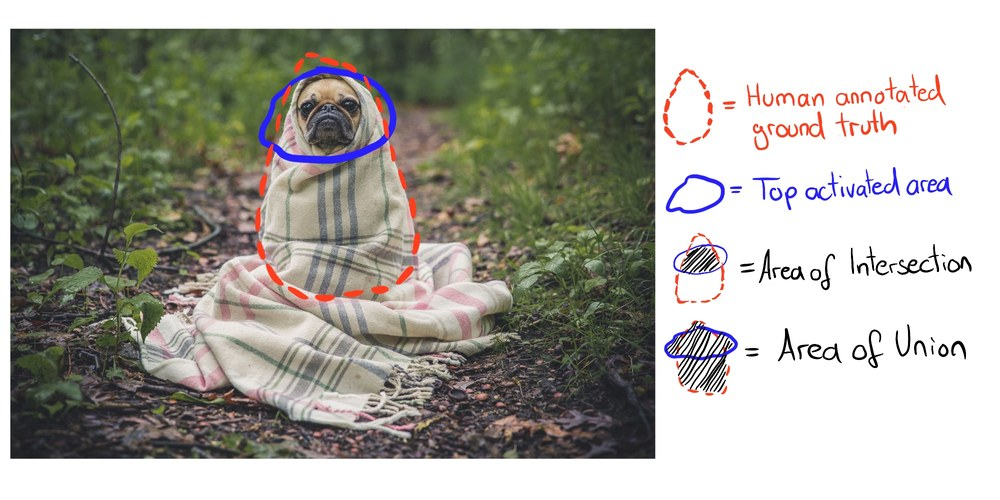

**Interseção**

Pixels que estão nas duas máscaras: onde a unidade dispara **e** há cachorro.

**União**

Pixels que estão em pelo menos uma. Dividir pela união pune as duas falhas: disparar fora do cachorro e não cobrir o cachorro.

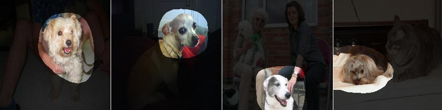

Canal 750 da camada inception_4e do GoogLeNet: detector de cachorros, IoU = 0,203.

[Molnar (2025)](https://christophm.github.io/interpretable-ml-book/cnn-features.html#algorithm), figuras *dissection-dog-exemplary* e *dissection-dogs* (esta, do [site do Network Dissection](http://netdissect.csail.mit.edu/)).

## Reprodução: dissecando a nossa CNN

Na conv1, 12 das 16 unidades são detectores, de 7 conceitos: orientações, bordas e junções, com IoU até 0,128. Na conv2, só 3 das 32 — o resto não corresponde a nenhum conceito do mini-Broden. Nenhuma unidade detecta buracos, pontas ou a classe do dígito.

Protocolo de [Bau et al. (2017)](https://arxiv.org/abs/1704.05796), §2.2, nas 10.000 imagens de teste do MNIST: ativações após a ReLU, quantil 0,995 (o controle mostra 0,99 e 0,999), ampliação bilinear de 14 × 14 para 28 × 28 na conv2, limiar 0,04. Imagens: as 4 de maior ativação da unidade.

## O que o artigo encontrou

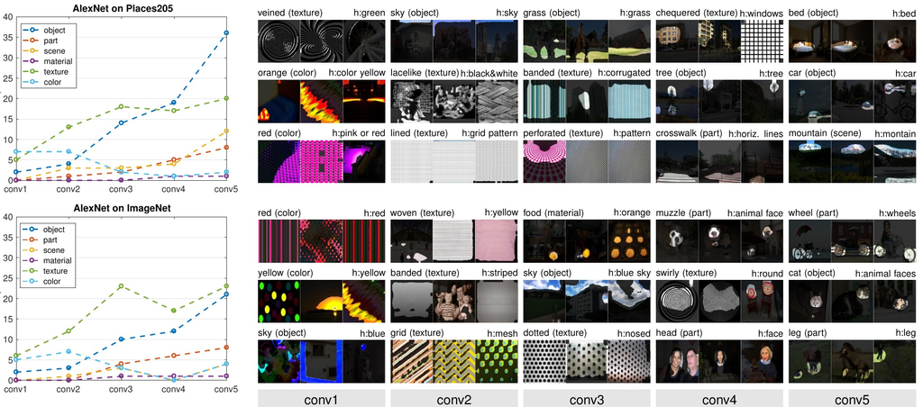

**Camadas**

Cores e texturas em conv1–conv2; partes e objetos em conv5. Avaliadores acharam descritivos 71% dos rótulos automáticos das unidades de conv5 (e 91% dos rótulos humanos).

**Arquitetura e dados**

ResNet > VGG > GoogLeNet > AlexNet; Places > ImageNet. No VGG do ImageNet, 95 canais detectam cachorro.

**Supervisão e treino**

Redes auto-supervisionadas têm menos detectores de objetos. Batch norm reduz a interpretabilidade; camadas mais largas a aumentam.

**Transferência**

Ao ajustar uma rede de objetos para classificar cenas, um detector de cachorro virou detector de cachoeira.

[Bau et al. (2017)](https://arxiv.org/abs/1704.05796), fig. 5 (reproduzida para fins didáticos), tab. 3, §3.4–3.7 e fig. 7–13; 95 canais de cachorro (4 em conv4_3, 91 em conv5_3) e transferência: [Molnar (2025)](https://christophm.github.io/interpretable-ml-book/cnn-features.html#experiments), com dados do [site do projeto](http://netdissect.csail.mit.edu/) e de [Zhou et al. (2019)](https://doi.org/10.1109/TPAMI.2018.2858759).

## Interpretabilidade depende dos eixos

Se conceitos aparecessem em qualquer direção do espaço de ativações, girar a base não mudaria nada. Bau et al. giraram os 256 canais da conv5 da AlexNet por uma rotação aleatória $Q^\alpha$:

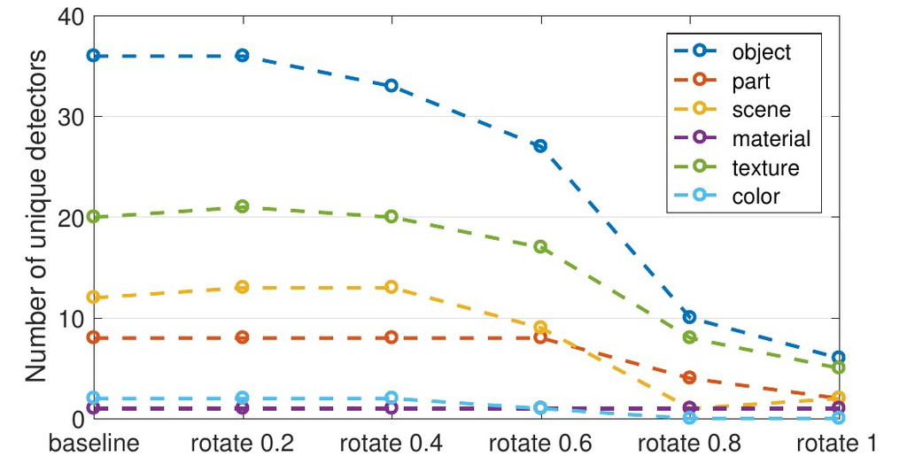

[figure not shown]

**Mesmo poder discriminativo**

Com $\mathbf r=Q\,f(\mathbf x)$ e $g'(\mathbf r)=g(Q^\top\mathbf r)$, a rede faz exatamente as mesmas previsões. Mas, em $\alpha=1$, há 80% menos detectores únicos: interpretabilidade não é consequência da acurácia.

**Na nossa CNN**

Na conv2, a rotação quase apaga os detectores, e a IoU média do melhor conceito de cada unidade cai 32%. Na conv1, não: combinações de detectores de borda continuam sendo detectores de borda.

[Bau et al. (2017)](https://arxiv.org/abs/1704.05796), §3.2 e fig. 4 (reproduzida para fins didáticos). Reprodução: $Q$ uniforme em SO(16) e SO(32) (QR de uma matriz normal), $Q^\alpha$ por potência fracionária, aplicada às ativações de cada posição; 3 sorteios de $Q$ (faixa: mínimo e máximo).

# Detecting concepts

## De atributos a conceitos

A importância de um pixel isolado diz pouco, e uma explicação por atributos fica presa aos atributos de entrada. Um **conceito** pode ser qualquer abstração — uma cor, um objeto, uma ideia — definida por quem pergunta, por meio de exemplos.

[figure not shown]

TCAV (*Testing with Concept Activation Vectors*) responde a uma pergunta global: quanto o conceito “listrado” influencia a classe “zebra”? A rede nunca foi treinada com o rótulo “listrado”.

[Molnar (2025), *Detecting Concepts*](https://christophm.github.io/interpretable-ml-book/detecting-concepts.html) (capítulo de Fangzhou Li); [Kim et al. (2018)](https://arxiv.org/abs/1711.11279). Na reprodução, 50 imagens por conceito, desenhadas com o traço do MNIST (posição, tamanho, espessura e inclinação sorteados), e conjuntos aleatórios de 50 dígitos de treino.

## CAV: um conceito vira uma direção

Leve os dois conjuntos até uma camada $l$ (o *bottleneck*), treine um classificador linear que separe as ativações do conceito das aleatórias e fique com o vetor normal à fronteira: o CAV $\mathbf v_l^C$.

Ativações reais da camada densa (64 unidades, antes da ReLU) da CNN da aula, projetadas no plano formado pelo CAV e pela principal direção de variação restante. Classificador: regressão logística (Molnar sugere SVM ou regressão logística). Setas: gradiente do logit, projetado e reescalado. Miniaturas: as 8 primeiras das 50 imagens de cada conjunto (conceitos desenhados e dígitos de treino sorteados).

## Sensibilidade conceitual e TCAV score

Se empurrarmos a ativação $\mathbf a=\hat f_l(\mathbf x)$ um pouquinho, $\varepsilon$, na direção do conceito, o logit da classe $k$ muda, em primeira ordem, $h(\mathbf a+\varepsilon\mathbf v)\approx h(\mathbf a)+\varepsilon\,\nabla h(\mathbf a)\cdot\mathbf v$. O coeficiente de $\varepsilon$ é a derivada direcional:

$$S_{C,k,l}(\mathbf x)=\nabla h_{l,k}\big(\hat f_l(\mathbf x)\big)\cdot\mathbf v_l^C
\qquad\qquad
\mathrm{TCAV}_{Q,C,k,l}=\frac{\big\lvert\{\mathbf x\in X_k : S_{C,k,l}(\mathbf x)>0\}\big\rvert}{\lvert X_k\rvert}$$

**$C$**

O conceito, definido por um conjunto de exemplos: “listrado”, “anel”.

**$k$**

A classe cuja saída se mede: “zebra”, o dígito 0.

**$l$**

A camada onde o conceito vira direção (o *bottleneck*): mixed4c, a densa.

**$\hat f_l(\mathbf x)$**

Ativações da camada $l$ para a entrada $\mathbf x$.

**$h_{l,k}$**

O resto da rede: das ativações da camada $l$ até o logit da classe $k$.

**$\mathbf v_l^C$**

O CAV, com norma 1.

**$S>0$**

O ângulo entre o gradiente e o CAV é menor que 90°: mais conceito, mais classe $k$.

**$X_k$**

As entradas da classe $k$. O TCAV score é a fração delas com $S>0$.

**$Q$**

Não é um índice: é o Q de TCAV<sub>Q</sub>, a medida quantitativa (o *score*) de Kim et al. Os índices são $C$, $k$ e $l$.

TCAV = 0,8 para “listrado” e “zebra”: em 80% das imagens de zebra, mais “listrado” aumentaria o logit de “zebra”. O sinal de $S$ só depende do ângulo entre $\nabla h$ e $\mathbf v$.

[Molnar (2025)](https://christophm.github.io/interpretable-ml-book/detecting-concepts.html#concept-activation-vector-cav), *Concept Activation Vector* e *Testing with CAVs*; [Kim et al. (2018)](https://arxiv.org/abs/1711.11279), §3.4, que chama a medida de TCAV<sub>Q</sub>. A aproximação de primeira ordem é a mesma da descida do gradiente na [Aula 13](https://brunogrisci.github.io/aulas-interpretabilidade/aula13.html).

## O TCAV score é significativo?

O CAV depende do conjunto aleatório sorteado. Se ele for ruim, o score engana. O teste repete tudo com vários conjuntos aleatórios e compara com CAVs de puro acaso:

**1 · Repetir**

$N\ge10$ conjuntos aleatórios; um CAV e um TCAV score com cada um, mantendo o conjunto do conceito.

→

**2 · Controle**

$N$ CAVs aleatórios: um conjunto aleatório no papel de “conceito”, contra outro.

→

**3 · Testar**

Teste t bilateral entre os dois grupos de $N$ scores; correção de Bonferroni pelo número de conceitos.

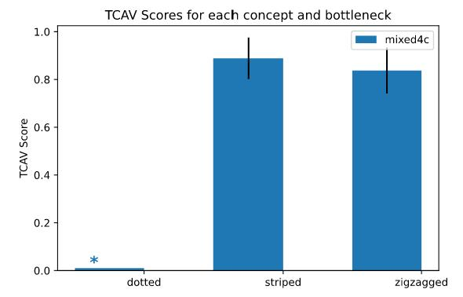

**Exemplo: GoogLeNet, “zebra”**

Na camada mixed4c, com 50 imagens por conjunto e 10 conjuntos aleatórios: “listrado” e “ziguezague” passam no teste; “pontilhado” (asterisco) não. Confira os pressupostos do teste t — ou use um teste não paramétrico.

[Molnar (2025)](https://christophm.github.io/interpretable-ml-book/detecting-concepts.html#testing-with-cavs-tcav) e *Example*, com a figura do notebook [Run_TCAV](https://github.com/tensorflow/tcav/blob/master/Run_TCAV.ipynb) do repositório tensorflow/tcav (Apache 2.0). O texto de Molnar fala em InceptionV3, mas o notebook usa o GoogLeNet ([Szegedy et al., 2015](https://arxiv.org/abs/1409.4842)), de onde vem a camada mixed4c.

## Reprodução: conceitos na nossa CNN

**barra azul**: significativa (p < 0,05, com Bonferroni) **barra cinza** com **✱** em cima: não passou no teste (p ≥ 0,05), como na figura da zebra altura: média dos 20 scores **ponto**: o TCAV score de um CAV (um por conjunto de negativos) **faixa**: os CAVs de controle (média ± 2 desvios)

Para o dígito 0, na camada densa, “anel” tem TCAV 0,98 e passa no teste; “pontilhado” (0,35) não. Um score baixo e significativo, como o de “barra horizontal”, indica que o conceito empurra **contra** a classe.

**Cuidado com os negativos.** Os conceitos são desenhos, e os aleatórios, dígitos: os CAVs dos conceitos compartilham uma direção “desenho, não dígito” (cosseno médio 0,38 na densa; com um CAV aleatório, 0,00). Com outros desenhos como negativos (CAV relativo), ela some (−0,13), e “anel” → 0 continua em 1,00: o anel se parece mesmo com o zero.

6 conceitos × 20 conjuntos de 50 negativos (dígitos de treino ou, no CAV relativo, os outros 5 desenhos: [Kim et al., 2018](https://arxiv.org/abs/1711.11279), §3.6); 500 imagens de teste por classe; regressão logística; Bonferroni para 6 conceitos; Mann–Whitney concorda em 162 de 180 casos. Acerto dos CAVs em imagens não vistas (validação cruzada): 91% a 99%; aleatório × aleatório: cerca de 50%. Nas imagens de treino, até aleatório × aleatório chega a 100% na pool1 e na pool2: esse acerto não serve de teste.

## O caso do 8

Um 8 tem dois laços, mas, na camada densa, “anel” tem TCAV 0,07 para o 8, baixo e significativo. Isso não quer dizer que a rede ignora laços:

[figure not shown]

**1 · Aqui o TCAV é quase 0 ou 1**

O gradiente do logit do 8 quase não muda entre imagens (cosseno ≥ 0,86 com a média). Assim, qualquer CAV dá TCAV perto de 0 ou de 1, até os de controle. O 0,07 diz que 18 dos 20 CAVs de “anel” baixam o logit do 8.

**2 · Para a rede, o anel é um zero**

Os anéis são lidos como 0, 6 ou 9, quase nunca como 8. Contra dígitos, o CAV ainda leva uma direção comum a todos os desenhos (sozinha, TCAV 0,00 para o 8). Um 8 desenhado sai 0,98; “dois anéis” × “anel”, 1,00 para o 8 e 0,00 para o 0.

**3 · Sentido, não tamanho**

Levar as ativações dos 8 até os anéis, ao longo do CAV, baixa P(8) só de 0,97 para 0,92. Contra outros desenhos (CAV relativo), os CAVs de “anel” vão de 0,01 a 1,00: média 0,71, não significativa.

“Anel contra o 8”: andar na direção “um laço só”, definida contra dígitos, afasta um pouco do 8. Antes de ler um TCAV: o que a rede vê no conceito, quais os negativos, como os CAVs se espalham ante o controle e qual o tamanho do efeito.

Camada densa (64 unidades, antes da ReLU); 500 imagens de teste do 8; os 20 conjuntos de dígitos do slide anterior; “dois anéis”: 50 desenhos no traço dos conceitos, fora do experimento principal. p: t bilateral contra o controle do mesmo grupo, × 6. Direção comum: média dos CAVs dos 6 conceitos contra dígitos (cosseno 0,48 com o de “anel”).

## Vantagens e limites do TCAV

**Vantagens**

- **Sem conhecimento de ML**: basta juntar exemplos do conceito — útil para especialistas do domínio.
- **Customizável**: qualquer conceito que caiba num conjunto de exemplos, mais simples ou mais fino.
- **Global**: relaciona conceitos a classes e ajuda a achar falhas: um classificador de zebras sensível a “pontilhado” sugere dados de treino desbalanceados.

**Limites**

- **Redes rasas**: conceitos ficam mais separáveis nas camadas profundas ([Alain e Bengio, 2016](https://arxiv.org/abs/1610.01644)).
- **Anotação**: cada conceito exige um conjunto de exemplos.
- **Conceitos abstratos**, como “felicidade”, exigem muitos dados.
- Pouco usado em **texto e tabelas**.

O CAV é uma sonda linear (*linear probe*) com um uso novo: a direção serve para medir a sensibilidade da saída. Sondas lineares e seus limites voltam na [Aula 20](https://brunogrisci.github.io/aulas-interpretabilidade/aula20.html).

[Molnar (2025)](https://christophm.github.io/interpretable-ml-book/detecting-concepts.html#strengths), *Strengths* e *Limitations*.

## Outras abordagens de conceitos

**ACE: conceitos automáticos**

*Automated Concept-based Explanation*: segmenta as imagens de uma classe, agrupa os segmentos pelas ativações e trata cada grupo como um conceito — sem anotação humana.

**CBM: concept bottleneck models**

Um modelo intrinsecamente interpretável: a primeira metade leva a entrada a conceitos; a segunda prevê a saída **só** a partir deles. Dá para intervir: corrigir um conceito e ver a previsão mudar.

**CW: concept whitening**

Troca uma camada de normalização (como o batch norm) por uma que branqueia as ativações e alinha eixos a conceitos: um classificador pré-treinado vira interpretável, mantendo o desempenho.

TCAV e ACE explicam uma rede pronta (post-hoc); CBM e CW mudam a rede para que os conceitos façam parte do modelo.

[Molnar (2025)](https://christophm.github.io/interpretable-ml-book/detecting-concepts.html#other-concept-based-approaches), *Other concept-based approaches*; [Ghorbani et al. (2019)](https://arxiv.org/abs/1902.03129); [Koh et al. (2020)](https://arxiv.org/abs/2007.04612); [Chen, Bei e Rudin (2020)](https://doi.org/10.1038/s42256-020-00265-z).

## Reprodução: um concept bottleneck

Uma CNN prevê 14 conceitos de cada dígito; uma regressão logística prevê o dígito só a partir desses 14 números. Clique num conceito para intervir.

[interactive chart not shown]

Teste: CNN comum 98,7%; CBM 88,5%, pois 14 conceitos não descrevem tudo. Trocar os conceitos previstos pelos das regras dá 82,7%: aqui, os “rótulos” são regras imperfeitas. Com probabilidades em vez de 0/1, 94,8%: o gargalo vaza informação.

Conceitos por imagem tirados das máscaras do mini-Broden (regiões relativas à caixa do traço). CNN da aula com 14 saídas sigmoides e entropia cruzada binária (Adam, 3 épocas); acerto médio dos conceitos no teste: 83% a 96%. Saída: regressão logística treinada nos conceitos das regras (o CBM “independente” de [Koh et al., 2020](https://arxiv.org/abs/2007.04612)); o de 94,8% é a versão sequencial, treinada nas probabilidades previstas. Vazamento de informação pelo gargalo: [Mahinpei et al. (2021)](https://arxiv.org/abs/2106.13314).

# Riscos e limites

## A ilusão de interpretabilidade

**Antropomorfizar**

Ver no neurônio 349 da camada 7 um “detector de margaridas” e achar que entendemos a rede. Muitas visualizações não correspondem a nenhuma palavra; pareidolia é humana ([Aula 03](https://brunogrisci.github.io/aulas-interpretabilidade/aula03.html)).

**Escolher a dedo**

As próprias fontes avisam: direções “escolhidas a dedo pela interpretabilidade” (Olah et al.), exemplos “escolhidos a dedo por brevidade” (Carter et al.). Uma galeria bonita não é uma amostra.

**Unidades demais**

O Inception V1 tem mais de 5.000 canais: com as visualizações positiva e negativa e 4 exemplos de cada lado, são mais de 50.000 imagens.

**Emaranhamento**

Canais interagem, várias unidades aprendem quase a mesma feature, positivo e negativo não se relacionam. Mesmo com Network Dissection, o IoU é modesto: no VGG, 193 dos 512 canais da conv5_3 não casam com conceito algum.

**Custo dos rótulos**

Network Dissection exige conceitos rotulados pixel a pixel; o TCAV, conjuntos de exemplos. E o Network Dissection só olha as ativações positivas.

**O que fica**

Uma visão única de como as redes funcionam — bordas primeiro, partes e objetos depois —, uma medida de interpretabilidade por unidade e uma boa forma de comunicar isso a não especialistas.

[Molnar (2025)](https://christophm.github.io/interpretable-ml-book/cnn-features.html#limitations), *Strengths* e *Limitations*; [Olah et al. (2017)](https://distill.pub/2017/feature-visualization/#interaction); [Carter et al. (2019)](https://distill.pub/2019/activation-atlas/).

## Síntese

| método | pergunta | precisa de | cuidado |
| --- | --- | --- | --- |
| Feature Selection Layer | que atributos de entrada a rede usa? | dados tabulares | multiclasse; imagens |
| feature visualization | que entrada mais ativa uma unidade? | gradiente na entrada | alta frequência; o prior também desenha |
| dataset examples | que imagens reais mais a ativam? | só forward | correlação não é causa |
| DeepDream | o que a camada amplifica numa foto? | gradiente na entrada | pareidolia: arte, não explicação |
| activation atlas | que combinações de neurônios ocorrem? | muitas amostras | depende da projeção 2D |
| Network Dissection | a unidade detecta um conceito humano? | rótulos pixel a pixel | IoU modesto; muitas unidades sem conceito |
| TCAV | um conceito influencia uma classe? | exemplos do conceito | conjuntos aleatórios; teste estatístico |
| concept bottleneck | e se o modelo passasse por conceitos? | conceitos anotados | acurácia; vazamento pelo gargalo |

Visualizar sugere; medir testa. Nenhuma dessas ferramentas, sozinha, explica uma rede: são blocos para combinar — por exemplo, com os mapas de atribuição das próximas aulas.

## Reprodutibilidade

Todas as redes desta aula foram escritas em NumPy, com o backpropagation até a entrada escrito à mão; semente 2026 e uma thread de BLAS.

| experimento | dados | modelo e protocolo | resultado |
| --- | --- | --- | --- |
| FSL embutida × post-hoc | XOR (500 × 50); SynthA (3.000 × 100); pinguins (333 × 10) | código oficial: MLP com batch norm e dropout, AdamW, L1 λ = 0,0025, 11 dobras | PIFS = PSFI = 1 (XOR); 0,861 (SynthA, post-hoc); pinguins: acurácia 0,905 (post-hoc) |
| CNN da aula | MNIST 60 mil / 10 mil | conv 5 × 5 (16) → conv 5 × 5 (32) → 64 → 10; Adam, 3 épocas | 98,7% no teste |
| feature visualization | — | Adam na entrada, 512 passos, 6 regularizações | logits: protótipos de dígitos |
| dataset examples · DeepDream | MNIST teste | máximo espacial; 40 iterações, jitter 2 px | 30 de 32 canais com ≥ 2 dígitos |
| activation atlas | 20 mil imagens de treino | t-SNE, grade 14 × 14, inversão com frequência penalizada | 128 células |
| Network Dissection | MNIST teste + 23 conceitos | quantil 0,995, IoU > 0,04; rotações $Q^\alpha$ | conv1 12/16; conv2 3/32 |
| TCAV | 6 conceitos × 50; 20 aleatórios | regressão logística, t bilateral + Bonferroni; Mann–Whitney; CAV relativo | “anel” → 0: 0,98 |
| concept bottleneck | MNIST + 14 conceitos | CNN → sigmoides → regressão logística | 88,5% |

Hiperparâmetros completos nas notas de cada slide. Os interativos só leem os resultados pré-calculados; os sprites da *Distill* são os dos artigos originais (CC BY 4.0).

# Referências

## Referências I

- Molnar, C. (2025). [*Interpretable Machine Learning*](https://christophm.github.io/interpretable-ml-book/). 3. ed. Capítulos [*Learned Features*](https://christophm.github.io/interpretable-ml-book/cnn-features.html) e [*Detecting Concepts*](https://christophm.github.io/interpretable-ml-book/detecting-concepts.html) (de Fangzhou Li).
- Olah, C.; Mordvintsev, A.; Schubert, L. (2017). [Feature visualization](https://doi.org/10.23915/distill.00007). *Distill*, 2(11).
- Carter, S.; Armstrong, Z.; Schubert, L.; Johnson, I.; Olah, C. (2019). [Exploring neural networks with activation atlases](https://doi.org/10.23915/distill.00015). *Distill*, 4(3).
- Olah, C. *et al.* (2018). [The building blocks of interpretability](https://doi.org/10.23915/distill.00010). *Distill*, 3(3).
- Bau, D.; Zhou, B.; Khosla, A.; Oliva, A.; Torralba, A. (2017). [Network dissection: quantifying interpretability of deep visual representations](https://doi.org/10.1109/CVPR.2017.354). *CVPR 2017*, 3319–3327.
- Zhou, B.; Bau, D.; Oliva, A.; Torralba, A. (2019). [Interpreting deep visual representations via network dissection](https://doi.org/10.1109/TPAMI.2018.2858759). *IEEE TPAMI*, 41(9), 2131–2145.

## Referências II

- Kim, B. *et al.* (2018). [Interpretability beyond feature attribution: quantitative testing with concept activation vectors (TCAV)](https://arxiv.org/abs/1711.11279). *ICML 2018*.
- Ghorbani, A.; Wexler, J.; Zou, J.; Kim, B. (2019). [Towards automatic concept-based explanations](https://arxiv.org/abs/1902.03129). *NeurIPS 32*.
- Koh, P. W. *et al.* (2020). [Concept bottleneck models](https://arxiv.org/abs/2007.04612). *ICML 2020*.
- Chen, Z.; Bei, Y.; Rudin, C. (2020). [Concept whitening for interpretable image recognition](https://doi.org/10.1038/s42256-020-00265-z). *Nature Machine Intelligence*, 2, 772–782.
- Mahinpei, A. *et al.* (2021). [Promises and pitfalls of black-box concept learning models](https://arxiv.org/abs/2106.13314). *arXiv:2106.13314*.
- Alain, G.; Bengio, Y. (2016). [Understanding intermediate layers using linear classifier probes](https://arxiv.org/abs/1610.01644). *arXiv:1610.01644*.
- Kokhlikyan, N. *et al.* (2020). [Captum: a unified and generic model interpretability library for PyTorch](https://arxiv.org/abs/2009.07896). *arXiv:2009.07896*.

## Referências III

- Figueroa Barraza, J.; López Droguett, E.; Martins, M. R. (2021). [Towards interpretable deep learning: a feature selection framework for prognostics and health management using deep neural networks](https://doi.org/10.3390/s21175888). *Sensors*, 21(17), 5888.
- Suwa, J. K.; Silva, J. P. S.; Grisci, B. I. (2026). [Post-hoc feature selection layer for neural networks interpretability](https://linklings.s3.amazonaws.com/organizations/WCCI/wcci2026/submissions/stype114/khrGU-ijcnn_pap3544s2.pdf). *IEEE International Joint Conference on Neural Networks (IJCNN 2026)*, Maastricht. Código e dados: github.com/joaosuwa/FSL_post-hoc.
- Grisci, B. I.; Inostroza-Ponta, M.; Dorn, M. (2025). [Assessing feature scorer results on high-dimensional datasets with t-SNE](https://doi.org/10.1016/j.neucom.2025.130561). *Neurocomputing*, 130561.
- Mordvintsev, A.; Olah, C.; Tyka, M. (2015). [Inceptionism: going deeper into neural networks](https://research.googleblog.com/2015/06/inceptionism-going-deeper-into-neural.html). *Google Research Blog*.
- Mordvintsev, A. (2016). [DeepDreaming with TensorFlow](https://github.com/tensorflow/tensorflow/blob/master/tensorflow/examples/tutorials/deepdream/deepdream.ipynb). Notebook.
- Wikipedia. [*DeepDream*](https://en.wikipedia.org/wiki/DeepDream) (revisão 1372994729).

## Referências IV

- Erhan, D.; Bengio, Y.; Courville, A.; Vincent, P. (2009). [*Visualizing higher-layer features of a deep network*](https://api.semanticscholar.org/CorpusID:15127402). Relatório técnico 1341, Université de Montréal.
- Szegedy, C. *et al.* (2013). [Intriguing properties of neural networks](https://arxiv.org/abs/1312.6199). *arXiv:1312.6199* (*ICLR 2014*).
- Mahendran, A.; Vedaldi, A. (2015). [Understanding deep image representations by inverting them](https://arxiv.org/abs/1412.0035). *CVPR 2015*.
- Nguyen, A.; Yosinski, J.; Clune, J. (2015). [Deep neural networks are easily fooled](https://arxiv.org/abs/1412.1897). *CVPR 2015*.
- Nguyen, A.; Yosinski, J.; Clune, J. (2016). [Multifaceted feature visualization](https://arxiv.org/abs/1602.03616). *ICML Visualization for Deep Learning Workshop*.
- Nguyen, A. *et al.* (2016a). [Synthesizing the preferred inputs for neurons in neural networks via deep generator networks](https://arxiv.org/abs/1605.09304). *NeurIPS 29*.
- Nguyen, A. *et al.* (2016b). [Plug & play generative networks](https://arxiv.org/abs/1612.00005). *arXiv:1612.00005* (*CVPR 2017*).

## Referências V

- Wei, D.; Zhou, B.; Torralba, A.; Freeman, W. (2015). [Understanding intra-class knowledge inside CNN](https://arxiv.org/abs/1507.02379). *arXiv:1507.02379*.
- Øygard, A. M. (2015). [Visualizing GoogLeNet classes](https://www.auduno.com/2015/07/29/visualizing-googlenet-classes/). Blog.
- Tyka, M. (2016). [Class visualization with bilateral filters](https://mtyka.github.io/deepdream/2016/02/05/bilateral-class-vis.html). Blog.
- Odena, A.; Dumoulin, V.; Olah, C. (2016). [Deconvolution and checkerboard artifacts](https://doi.org/10.23915/distill.00003). *Distill*, 1(10).
- Karpathy, A.; Johnson, J.; Fei-Fei, L. (2015). [Visualizing and understanding recurrent networks](https://arxiv.org/abs/1506.02078). *arXiv:1506.02078*.
- Szegedy, C. *et al.* (2015). [Going deeper with convolutions](https://arxiv.org/abs/1409.4842). *CVPR 2015*. (*GoogLeNet / Inception V1*)
- Szegedy, C. *et al.* (2016). [Rethinking the Inception architecture for computer vision](https://arxiv.org/abs/1512.00567). *CVPR 2016*. (*InceptionV3*)

## Referências VI

- McInnes, L.; Healy, J.; Melville, J. (2018). [UMAP: uniform manifold approximation and projection for dimension reduction](https://arxiv.org/abs/1802.03426). *arXiv:1802.03426*.
- van der Maaten, L.; Hinton, G. (2008). [Visualizing data using t-SNE](https://jmlr.org/papers/v9/vandermaaten08a.html). *JMLR*, 9, 2579–2605.
- Zhang, T. Y.; Suen, C. Y. (1984). [A fast parallel algorithm for thinning digital patterns](https://doi.org/10.1145/357994.358023). *Communications of the ACM*, 27(3), 236–239.
- LeCun, Y.; Cortes, C.; Burges, C. J. C. [*The MNIST database of handwritten digits*](http://yann.lecun.com/exdb/mnist/).
- Kingma, D. P.; Ba, J. (2015). [Adam: a method for stochastic optimization](https://arxiv.org/abs/1412.6980). *ICLR 2015*; Loshchilov, I.; Hutter, F. (2019). [Decoupled weight decay regularization](https://arxiv.org/abs/1711.05101) (AdamW). *ICLR 2019*.
- Harris, C. R. *et al.* (2020). [Array programming with NumPy](https://doi.org/10.1038/s41586-020-2649-2). *Nature*, 585, 357–362; Pedregosa, F. *et al.* (2011). [Scikit-learn: machine learning in Python](https://jmlr.org/papers/v12/pedregosa11a.html). *JMLR*, 12, 2825–2830.

## Referências VII

- Krizhevsky, A.; Sutskever, I.; Hinton, G. E. (2012). [ImageNet classification with deep convolutional neural networks](https://papers.nips.cc/paper/4824-imagenet-classification-with-deep-convolutional-neural-networks). *NeurIPS 25*. (*AlexNet*)
- Goodfellow, I. J.; Shlens, J.; Szegedy, C. (2015). [Explaining and harnessing adversarial examples](https://arxiv.org/abs/1412.6572). *ICLR 2015*.

## Referências VIII: vídeo e imagens

- Computerphile, com Mike Pound: [*Deep Dream (Google)*](https://www.youtube.com/watch?v=BsSmBPmPeYQ).
- Figuras e sprites dos interativos de [Olah et al. (2017)](https://distill.pub/2017/feature-visualization/) e de [Carter et al. (2019)](https://distill.pub/2019/activation-atlas/): *Distill*, CC BY 4.0.
- Figuras de [Bau et al. (2017)](https://arxiv.org/abs/1704.05796), da versão do arXiv, e figuras do [site do Network Dissection](http://netdissect.csail.mit.edu/), via [Molnar (2025)](https://christophm.github.io/interpretable-ml-book/cnn-features.html): reproduzidas para fins didáticos.
- Imagens de prior aprendido: figura 1 de [Nguyen et al. (2016a)](https://arxiv.org/abs/1605.09304) e de [Nguyen et al. (2016b)](https://arxiv.org/abs/1612.00005), versões do arXiv, extraídas do PDF sem reamostragem.
- Figura do TCAV: notebook [Run_TCAV](https://github.com/tensorflow/tcav/blob/master/Run_TCAV.ipynb), repositório tensorflow/tcav (Apache 2.0), via [Molnar (2025)](https://christophm.github.io/interpretable-ml-book/detecting-concepts.html).
- DeepDream: água-viva, MartinThoma (original, [10](https://commons.wikimedia.org/wiki/File:Aurelia-aurita-3-0009.jpg) e [50 iterações](https://commons.wikimedia.org/wiki/File:Aurelia-aurita-3-0049.jpg)); Mona Lisa com VGG16, [Pjfinlay](https://commons.wikimedia.org/wiki/File:%22Mona_Lisa%22_with_DeepDream_effect_using_VGG16_network_trained_on_ImageNet.jpg). Wikimedia Commons, CC0.
- Notebook [*Simple Activation Atlas*](https://colab.research.google.com/github/tensorflow/lucid/blob/master/notebooks/activation-atlas/activation-atlas-simple.ipynb) e biblioteca [Lucid](https://github.com/tensorflow/lucid) (Apache 2.0).

## Próxima aula

**[Aula 15: Saliency e Atribuição em Redes Neurais](https://brunogrisci.github.io/aulas-interpretabilidade/aula15.html)**

## Sobre os slides

Slides por [Bruno Iochins Grisci](https://brunogrisci.github.io/) com base nas referências da disciplina, em especial o livro [*Interpretable Machine Learning: A Guide for Making Black Box Models Explainable*](https://christophm.github.io/interpretable-ml-book/). 3. ed. (2025) por [Christoph Molnar](https://christophmolnar.com/). Nesta aula, também os artigos [*Feature Visualization*](https://distill.pub/2017/feature-visualization/) (2017), de Chris Olah, Alexander Mordvintsev e Ludwig Schubert, e [*Exploring Neural Networks with Activation Atlases*](https://distill.pub/2019/activation-atlas/) (2019), de Shan Carter, Zan Armstrong, Ludwig Schubert, Ian Johnson e Chris Olah, publicados na *Distill*.

Slides desenvolvidos usando [Quarto](https://quarto.org/) e [reveal.js](https://revealjs.com/) com auxílio de Claude Code e Opus 5.5.

## Licença e direitos autorais

© 2026 [Bruno Iochins Grisci](https://brunogrisci.github.io/). Alguns direitos reservados.

Exceto quando indicado em contrário, os textos, diagramas e demais elementos autorais próprios desta apresentação estão licenciados sob a Licença Creative Commons Atribuição–NãoComercial 4.0 Internacional (CC BY-NC 4.0):

https://creativecommons.org/licenses/by-nc/4.0/deed.pt-br

É permitida a cópia e o compartilhamento do material, para fins não comerciais, mediante atribuição adequada da autoria.

Imagens, citações, marcas, logotipos e demais materiais de terceiros não estão abrangidos por esta licença e permanecem sujeitos às respectivas licenças e direitos autorais indicados junto a cada item.

Para uso comercial, adaptações ou outras permissões, entre em contato com o [autor](https://brunogrisci.github.io/).